# Assignment1

Michael Koch

9/15/2021

```r
set.seed(0704)
```

```r
library(tidyverse)
library(kableExtra)
```

In this Exercise, I’m performing a little [Monte Carlo](https://www.youtube.com/watch?v=PQCYjl32_Sk) simulation study which is ought to illustrate the following:

**“A replication of the procedure that generates a 95% confidence interval that is centered around the sample mean would cover the population value at least 95 out of 100 times”** [(Neyman, 1934)](http://www.stat.cmu.edu/~brian/905-2008/papers/neyman-1934-jrss.pdf).

First, I need to sample 100 samples (N = 10000) from a standard normal distribution, and calculate the following quantities from the samples:

- absolute bias
- standard error
- lower bound & upperbound of the 95% C.I.

In order to take the samples, I copy Gerko’s approach from class, where I take advantage of `plyr::rlply`.

```r
samples <- plyr::rlply(100, rnorm(10000, 0, 1))
```

To tackle the sample statistics, I first write a helper function `CalculateSampStats()`, which I can later use very straightforwardly within a pipe, as Gerko has illustrated in class.

```r
CalculateSampStats <- function(samples){

  n <- length(samples)
  mean <- mean(samples)
  bias <- abs(0-mean)
  df <- n - 1
  se <- 1/ sqrt(n)
  z <- qnorm(1-0.05/2)
  lowerBound <- mean - z*se
  upperBound <- mean + z*se

  output <- c(mean = mean,
              bias = bias,
              se = se,
              lower = lowerBound,
              upper = upperBound)
  return(output)

}

# for calling vapply
format <- c("mean" = 0, "bias" = 0, "se" = 0, "lower" = 0, "upper" = 0)
```

Now I can `vapply` my function to all samples, using pipes. This is a use-case where `vapply` shines, as chosing my own output format is quite handy here. Note that I’m also adding a dummy variable in this step, that is 1 whenever the C.I. contains the true mean $\mu = 0$. The mean of this variable later represents the percentage of 95% C.I.’s covering the true value of 0.

```r
sampStats <-
  samples %>%
    vapply(., CalculateSampStats, format ) %>%
    t %>%
    as_tibble %>%
    mutate(covers = ifelse(lower < 0 & upper > 0, 1, 0))
```

```r
mean(sampStats$covers)
```

```
## [1] 0.97
```

Now, it seems that **approximately** 95% of the 95% confidence interval do cover the true value - brilliant.

We can make a plot to illustrate this further. I’m using `ggplot's` `geom_pointrage` for this - the perfect geom for this purpose.

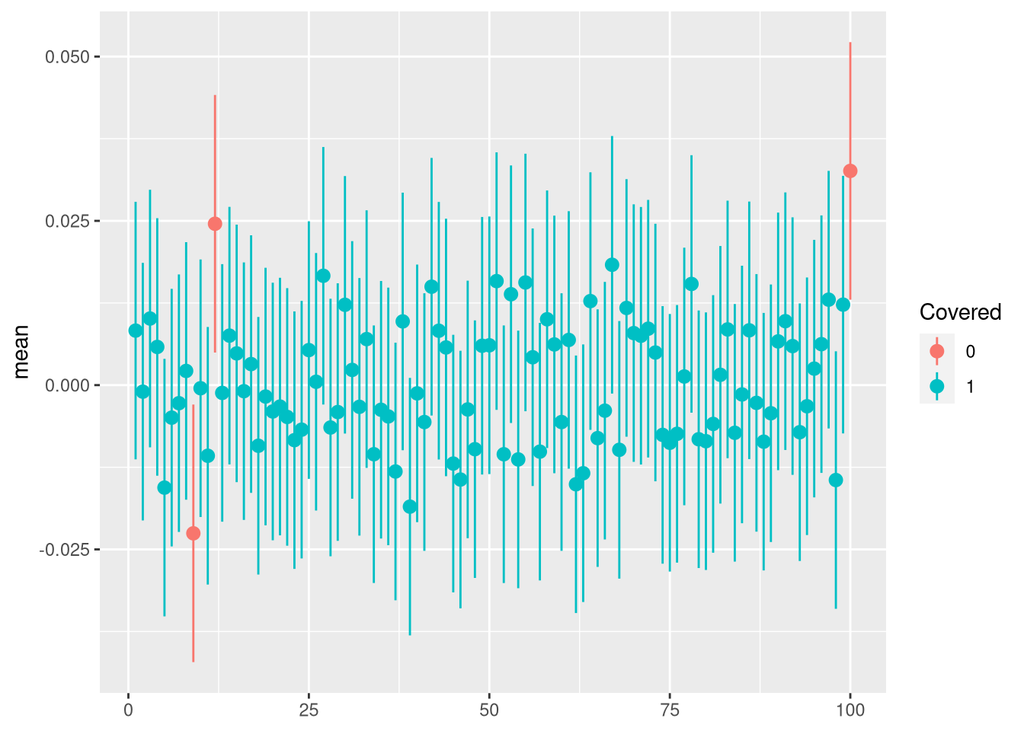

```r
# specify limits for geom_pointrage
lims <- aes(ymax = upper, ymin = lower, col = as.factor(covers))

sampStats %>%
  ggplot(aes(y = mean, x = 1:100))+
  geom_pointrange(lims)+
  labs(x = NULL,
       col = "Covered",
       main = "")
```

Indeed, we can see that 3 out of 100 (3%) do not contain the true value of $\mu = 0$.

At last, I add a nice table with the sample stats of those samples where the C.I. did not contain the true mean. Nice tables can be done with `kable()`. By the way, there’s also a bunch of packages for APA-style tables (I recommend just using [`papaja`](https://github.com/crsh/papaja)).

```r
sampStats %>%
  filter(covers == 0) %>%
  kable() %>%
  kable_styling(full_width = T)
```

| mean | bias | se | lower | upper | covers |
| --- | --- | --- | --- | --- | --- |
| -0.0225563 | 0.0225563 | 0.01 | -0.0421559 | -0.0029567 | 0 |
| 0.0245566 | 0.0245566 | 0.01 | 0.0049569 | 0.0441562 | 0 |
| 0.0326022 | 0.0326022 | 0.01 | 0.0130026 | 0.0522018 | 0 |